# Energy Data

## Задание 2: Моделирование энергопотребления в здании

**Автор:** Собченко Анастасия Алексеевна  
**Дата:** 29 сентября 2024 г.  
**Версия:** 1.0

## Описание проекта

**Ссылка на датасет:** https://archive.ics.uci.edu/dataset/374/appliances+energy+prediction

1. Анализ данных: Изучите временные ряды данных об энергопотреблении. Постройте графики зависимости энергопотребления от времени суток и дня недели.
2. Обработка данных: Обработайте пропуски и выбросы в данных. Создайте новые признаки, такие как день недели, время суток, температура и влажность, для улучшения прогноза.
3. Моделирование: Постройте модель временных рядов для прогнозирования энергопотребления в будущем. Используйте модели машинного обучения (например,линейную регрессию, XGBoost) для прогнозирования энергопотребления на следующий день.
4. Оценка модели: Оцените точность прогноза с использованием метрик, таких как MAE, RMSE. Проанализируйте, какие факторы оказывают наибольшее влияние на потребление энергии. Интерпретация результатов и рекомендации: Подготовьте отчет с предложениями по оптимизации энергопотребления в здании

## Содержание

1. Анализ данных
- 1.1. Импорт данных, пропущенные значения, описательная статистика
- 1.2. Целевая переменная Appliances
- 1.3. Корреляции
- 1.4. Визуализации
2. Временной ряд. Модель SARIMAX
3. Модели
- 3.1. Подготовка train, test
- 3.2. Линейная регрессия
- 3.3. Lasso регрессия, Ridge регрессия
- 3.4. RandomForestRegressor. Случайный лес
- 3.5. XGB Regressor
- 3.6. CatBoost
4. Заключение

## Контакты

**Email:** lobzinastya@gmail.com

# 1. Анализ данных

## 1.1. Импорт данных, пропущенные значения, описательная статистика

```python
import pandas as pd
import numpy as np
import matplotlib.pyplot as plt
import seaborn as sns


from sklearn.model_selection import train_test_split
from sklearn.preprocessing import StandardScaler
from sklearn.linear_model import LinearRegression
from sklearn.linear_model import Lasso, Ridge
from sklearn.ensemble import RandomForestRegressor
import xgboost as xgb
from catboost import CatBoostRegressor
from sklearn.metrics import mean_absolute_error, mean_squared_error, r2_score


from pmdarima import auto_arima
from statsmodels.tsa.statespace.sarimax import SARIMAX
from statsmodels.tsa.stattools import adfuller

sns.set_style('white')
palette_color = sns.color_palette('viridis', n_colors = 7)
#two_colors = [palette_color[0],palette_color[-1]]
pd.set_option('display.max_columns', None)
# import warnings
# warnings.filterwarnings("ignore")
%matplotlib inline
```

```python
file_path = ''
df = pd.read_csv(file_path + 'energydata_complete.csv')
df
```

|  | date | Appliances | lights | T1 | RH_1 | T2 | RH_2 | T3 | RH_3 | T4 | RH_4 | T5 | RH_5 | T6 | RH_6 | T7 | RH_7 | T8 | RH_8 | T9 | RH_9 | T_out | Press_mm_hg | RH_out | Windspeed | Visibility | Tdewpoint | rv1 | rv2 |
| --- | --- | --- | --- | --- | --- | --- | --- | --- | --- | --- | --- | --- | --- | --- | --- | --- | --- | --- | --- | --- | --- | --- | --- | --- | --- | --- | --- | --- | --- |
| 0 | 2016-01-11 17:00:00 | 60 | 30 | 19.890000 | 47.596667 | 19.200000 | 44.790000 | 19.790000 | 44.730000 | 19.000000 | 45.566667 | 17.166667 | 55.200000 | 7.026667 | 84.256667 | 17.200000 | 41.626667 | 18.2000 | 48.900000 | 17.033333 | 45.5300 | 6.600000 | 733.5 | 92.000000 | 7.000000 | 63.000000 | 5.300000 | 13.275433 | 13.275433 |
| 1 | 2016-01-11 17:10:00 | 60 | 30 | 19.890000 | 46.693333 | 19.200000 | 44.722500 | 19.790000 | 44.790000 | 19.000000 | 45.992500 | 17.166667 | 55.200000 | 6.833333 | 84.063333 | 17.200000 | 41.560000 | 18.2000 | 48.863333 | 17.066667 | 45.5600 | 6.483333 | 733.6 | 92.000000 | 6.666667 | 59.166667 | 5.200000 | 18.606195 | 18.606195 |
| 2 | 2016-01-11 17:20:00 | 50 | 30 | 19.890000 | 46.300000 | 19.200000 | 44.626667 | 19.790000 | 44.933333 | 18.926667 | 45.890000 | 17.166667 | 55.090000 | 6.560000 | 83.156667 | 17.200000 | 41.433333 | 18.2000 | 48.730000 | 17.000000 | 45.5000 | 6.366667 | 733.7 | 92.000000 | 6.333333 | 55.333333 | 5.100000 | 28.642668 | 28.642668 |
| 3 | 2016-01-11 17:30:00 | 50 | 40 | 19.890000 | 46.066667 | 19.200000 | 44.590000 | 19.790000 | 45.000000 | 18.890000 | 45.723333 | 17.166667 | 55.090000 | 6.433333 | 83.423333 | 17.133333 | 41.290000 | 18.1000 | 48.590000 | 17.000000 | 45.4000 | 6.250000 | 733.8 | 92.000000 | 6.000000 | 51.500000 | 5.000000 | 45.410389 | 45.410389 |
| 4 | 2016-01-11 17:40:00 | 60 | 40 | 19.890000 | 46.333333 | 19.200000 | 44.530000 | 19.790000 | 45.000000 | 18.890000 | 45.530000 | 17.200000 | 55.090000 | 6.366667 | 84.893333 | 17.200000 | 41.230000 | 18.1000 | 48.590000 | 17.000000 | 45.4000 | 6.133333 | 733.9 | 92.000000 | 5.666667 | 47.666667 | 4.900000 | 10.084097 | 10.084097 |
| ... | ... | ... | ... | ... | ... | ... | ... | ... | ... | ... | ... | ... | ... | ... | ... | ... | ... | ... | ... | ... | ... | ... | ... | ... | ... | ... | ... | ... | ... |
| 19730 | 2016-05-27 17:20:00 | 100 | 0 | 25.566667 | 46.560000 | 25.890000 | 42.025714 | 27.200000 | 41.163333 | 24.700000 | 45.590000 | 23.200000 | 52.400000 | 24.796667 | 1.000000 | 24.500000 | 44.500000 | 24.7000 | 50.074000 | 23.200000 | 46.7900 | 22.733333 | 755.2 | 55.666667 | 3.333333 | 23.666667 | 13.333333 | 43.096812 | 43.096812 |
| 19731 | 2016-05-27 17:30:00 | 90 | 0 | 25.500000 | 46.500000 | 25.754000 | 42.080000 | 27.133333 | 41.223333 | 24.700000 | 45.590000 | 23.230000 | 52.326667 | 24.196667 | 1.000000 | 24.557143 | 44.414286 | 24.7000 | 49.790000 | 23.200000 | 46.7900 | 22.600000 | 755.2 | 56.000000 | 3.500000 | 24.500000 | 13.300000 | 49.282940 | 49.282940 |
| 19732 | 2016-05-27 17:40:00 | 270 | 10 | 25.500000 | 46.596667 | 25.628571 | 42.768571 | 27.050000 | 41.690000 | 24.700000 | 45.730000 | 23.230000 | 52.266667 | 23.626667 | 1.000000 | 24.540000 | 44.400000 | 24.7000 | 49.660000 | 23.200000 | 46.7900 | 22.466667 | 755.2 | 56.333333 | 3.666667 | 25.333333 | 13.266667 | 29.199117 | 29.199117 |
| 19733 | 2016-05-27 17:50:00 | 420 | 10 | 25.500000 | 46.990000 | 25.414000 | 43.036000 | 26.890000 | 41.290000 | 24.700000 | 45.790000 | 23.200000 | 52.200000 | 22.433333 | 1.000000 | 24.500000 | 44.295714 | 24.6625 | 49.518750 | 23.200000 | 46.8175 | 22.333333 | 755.2 | 56.666667 | 3.833333 | 26.166667 | 13.233333 | 6.322784 | 6.322784 |
| 19734 | 2016-05-27 18:00:00 | 430 | 10 | 25.500000 | 46.600000 | 25.264286 | 42.971429 | 26.823333 | 41.156667 | 24.700000 | 45.963333 | 23.200000 | 52.200000 | 21.026667 | 1.000000 | 24.500000 | 44.054000 | 24.7360 | 49.736000 | 23.200000 | 46.8450 | 22.200000 | 755.2 | 57.000000 | 4.000000 | 27.000000 | 13.200000 | 34.118851 | 34.118851 |

19735 rows × 29 columns

```python
df.info()
```

```
<class 'pandas.core.frame.DataFrame'>
RangeIndex: 19735 entries, 0 to 19734
Data columns (total 29 columns):
 #   Column       Non-Null Count  Dtype
---  ------       --------------  -----
 0   date         19735 non-null  object
 1   Appliances   19735 non-null  int64
 2   lights       19735 non-null  int64
 3   T1           19735 non-null  float64
 4   RH_1         19735 non-null  float64
 5   T2           19735 non-null  float64
 6   RH_2         19735 non-null  float64
 7   T3           19735 non-null  float64
 8   RH_3         19735 non-null  float64
 9   T4           19735 non-null  float64
```

[output cut: 21 more lines]

Проверили наличие пропущенных значений, их нет

Приводим к формату datetime признак date

```python
df['date'] = pd.to_datetime(df['date'])
```

Описательная статистика для числовых переменных:

```python
df.describe().T
```

|  | count | mean | min | 25% | 50% | 75% | max | std |
| --- | --- | --- | --- | --- | --- | --- | --- | --- |
| date | 19735 | 2016-03-20 05:30:00 | 2016-01-11 17:00:00 | 2016-02-14 23:15:00 | 2016-03-20 05:30:00 | 2016-04-23 11:45:00 | 2016-05-27 18:00:00 | NaN |
| Appliances | 19735.0 | 97.694958 | 10.0 | 50.0 | 60.0 | 100.0 | 1080.0 | 102.524891 |
| lights | 19735.0 | 3.801875 | 0.0 | 0.0 | 0.0 | 0.0 | 70.0 | 7.935988 |
| T1 | 19735.0 | 21.686571 | 16.79 | 20.76 | 21.6 | 22.6 | 26.26 | 1.606066 |
| RH_1 | 19735.0 | 40.259739 | 27.023333 | 37.333333 | 39.656667 | 43.066667 | 63.36 | 3.979299 |
| T2 | 19735.0 | 20.341219 | 16.1 | 18.79 | 20.0 | 21.5 | 29.856667 | 2.192974 |
| RH_2 | 19735.0 | 40.42042 | 20.463333 | 37.9 | 40.5 | 43.26 | 56.026667 | 4.069813 |
| T3 | 19735.0 | 22.267611 | 17.2 | 20.79 | 22.1 | 23.29 | 29.236 | 2.006111 |
| RH_3 | 19735.0 | 39.2425 | 28.766667 | 36.9 | 38.53 | 41.76 | 50.163333 | 3.254576 |
| T4 | 19735.0 | 20.855335 | 15.1 | 19.53 | 20.666667 | 22.1 | 26.2 | 2.042884 |
| RH_4 | 19735.0 | 39.026904 | 27.66 | 35.53 | 38.4 | 42.156667 | 51.09 | 4.341321 |
| T5 | 19735.0 | 19.592106 | 15.33 | 18.2775 | 19.39 | 20.619643 | 25.795 | 1.844623 |
| RH_5 | 19735.0 | 50.949283 | 29.815 | 45.4 | 49.09 | 53.663333 | 96.321667 | 9.022034 |
| T6 | 19735.0 | 7.910939 | -6.065 | 3.626667 | 7.3 | 11.256 | 28.29 | 6.090347 |
| RH_6 | 19735.0 | 54.609083 | 1.0 | 30.025 | 55.29 | 83.226667 | 99.9 | 31.149806 |
| T7 | 19735.0 | 20.267106 | 15.39 | 18.7 | 20.033333 | 21.6 | 26.0 | 2.109993 |
| RH_7 | 19735.0 | 35.3882 | 23.2 | 31.5 | 34.863333 | 39.0 | 51.4 | 5.114208 |
| T8 | 19735.0 | 22.029107 | 16.306667 | 20.79 | 22.1 | 23.39 | 27.23 | 1.956162 |
| RH_8 | 19735.0 | 42.936165 | 29.6 | 39.066667 | 42.375 | 46.536 | 58.78 | 5.224361 |
| T9 | 19735.0 | 19.485828 | 14.89 | 18.0 | 19.39 | 20.6 | 24.5 | 2.014712 |
| RH_9 | 19735.0 | 41.552401 | 29.166667 | 38.5 | 40.9 | 44.338095 | 53.326667 | 4.151497 |
| T_out | 19735.0 | 7.411665 | -5.0 | 3.666667 | 6.916667 | 10.408333 | 26.1 | 5.317409 |
| Press_mm_hg | 19735.0 | 755.522602 | 729.3 | 750.933333 | 756.1 | 760.933333 | 772.3 | 7.399441 |
| RH_out | 19735.0 | 79.750418 | 24.0 | 70.333333 | 83.666667 | 91.666667 | 100.0 | 14.901088 |
| Windspeed | 19735.0 | 4.039752 | 0.0 | 2.0 | 3.666667 | 5.5 | 14.0 | 2.451221 |
| Visibility | 19735.0 | 38.330834 | 1.0 | 29.0 | 40.0 | 40.0 | 66.0 | 11.794719 |
| Tdewpoint | 19735.0 | 3.760707 | -6.6 | 0.9 | 3.433333 | 6.566667 | 15.5 | 4.194648 |
| rv1 | 19735.0 | 24.988033 | 0.005322 | 12.497889 | 24.897653 | 37.583769 | 49.99653 | 14.496634 |
| rv2 | 19735.0 | 24.988033 | 0.005322 | 12.497889 | 24.897653 | 37.583769 | 49.99653 | 14.496634 |

Как видно из описательной статистики данные по rv1 и rv2 совпадают (квантили, дисперсия)

А вдруг rv1 совпадает с rv2. Проверяем есть ли rv1!=rv2 (считам количество строк, где они не равны)

```python
(df['rv1']==df['rv2']).isna().sum()
```

```
0
```

```python
df.drop(columns = ['rv2'], inplace=True)
```

Благодаря данным описательной статистике, полученной с помощью describe мы знаем, что данные получены во временном интервале

от 2016-01-11 17:00:00 до 2016-05-27 18:00:00

```python
#df['year'] = df.date.dt.year
df['month'] = df.date.dt.month
df['weekday'] = df.date.dt.weekday
df['hour'] = df.date.dt.hour
df['day'] = df.date.dt.day
df['dayofyear'] = df['date'].dt.dayofyear
df
```

|  | date | Appliances | lights | T1 | RH_1 | T2 | RH_2 | T3 | RH_3 | T4 | RH_4 | T5 | RH_5 | T6 | RH_6 | T7 | RH_7 | T8 | RH_8 | T9 | RH_9 | T_out | Press_mm_hg | RH_out | Windspeed | Visibility | Tdewpoint | rv1 | month | … |
| --- | --- | --- | --- | --- | --- | --- | --- | --- | --- | --- | --- | --- | --- | --- | --- | --- | --- | --- | --- | --- | --- | --- | --- | --- | --- | --- | --- | --- | --- | --- |
| 0 | 2016-01-11 17:00:00 | 60 | 30 | 19.890000 | 47.596667 | 19.200000 | 44.790000 | 19.790000 | 44.730000 | 19.000000 | 45.566667 | 17.166667 | 55.200000 | 7.026667 | 84.256667 | 17.200000 | 41.626667 | 18.2000 | 48.900000 | 17.033333 | 45.5300 | 6.600000 | 733.5 | 92.000000 | 7.000000 | 63.000000 | 5.300000 | 13.275433 | 1 | … |
| 1 | 2016-01-11 17:10:00 | 60 | 30 | 19.890000 | 46.693333 | 19.200000 | 44.722500 | 19.790000 | 44.790000 | 19.000000 | 45.992500 | 17.166667 | 55.200000 | 6.833333 | 84.063333 | 17.200000 | 41.560000 | 18.2000 | 48.863333 | 17.066667 | 45.5600 | 6.483333 | 733.6 | 92.000000 | 6.666667 | 59.166667 | 5.200000 | 18.606195 | 1 | … |
| 2 | 2016-01-11 17:20:00 | 50 | 30 | 19.890000 | 46.300000 | 19.200000 | 44.626667 | 19.790000 | 44.933333 | 18.926667 | 45.890000 | 17.166667 | 55.090000 | 6.560000 | 83.156667 | 17.200000 | 41.433333 | 18.2000 | 48.730000 | 17.000000 | 45.5000 | 6.366667 | 733.7 | 92.000000 | 6.333333 | 55.333333 | 5.100000 | 28.642668 | 1 | … |
| 3 | 2016-01-11 17:30:00 | 50 | 40 | 19.890000 | 46.066667 | 19.200000 | 44.590000 | 19.790000 | 45.000000 | 18.890000 | 45.723333 | 17.166667 | 55.090000 | 6.433333 | 83.423333 | 17.133333 | 41.290000 | 18.1000 | 48.590000 | 17.000000 | 45.4000 | 6.250000 | 733.8 | 92.000000 | 6.000000 | 51.500000 | 5.000000 | 45.410389 | 1 | … |
| 4 | 2016-01-11 17:40:00 | 60 | 40 | 19.890000 | 46.333333 | 19.200000 | 44.530000 | 19.790000 | 45.000000 | 18.890000 | 45.530000 | 17.200000 | 55.090000 | 6.366667 | 84.893333 | 17.200000 | 41.230000 | 18.1000 | 48.590000 | 17.000000 | 45.4000 | 6.133333 | 733.9 | 92.000000 | 5.666667 | 47.666667 | 4.900000 | 10.084097 | 1 | … |
| ... | ... | ... | ... | ... | ... | ... | ... | ... | ... | ... | ... | ... | ... | ... | ... | ... | ... | ... | ... | ... | ... | ... | ... | ... | ... | ... | ... | ... | ... | … |
| 19730 | 2016-05-27 17:20:00 | 100 | 0 | 25.566667 | 46.560000 | 25.890000 | 42.025714 | 27.200000 | 41.163333 | 24.700000 | 45.590000 | 23.200000 | 52.400000 | 24.796667 | 1.000000 | 24.500000 | 44.500000 | 24.7000 | 50.074000 | 23.200000 | 46.7900 | 22.733333 | 755.2 | 55.666667 | 3.333333 | 23.666667 | 13.333333 | 43.096812 | 5 | … |
| 19731 | 2016-05-27 17:30:00 | 90 | 0 | 25.500000 | 46.500000 | 25.754000 | 42.080000 | 27.133333 | 41.223333 | 24.700000 | 45.590000 | 23.230000 | 52.326667 | 24.196667 | 1.000000 | 24.557143 | 44.414286 | 24.7000 | 49.790000 | 23.200000 | 46.7900 | 22.600000 | 755.2 | 56.000000 | 3.500000 | 24.500000 | 13.300000 | 49.282940 | 5 | … |
| 19732 | 2016-05-27 17:40:00 | 270 | 10 | 25.500000 | 46.596667 | 25.628571 | 42.768571 | 27.050000 | 41.690000 | 24.700000 | 45.730000 | 23.230000 | 52.266667 | 23.626667 | 1.000000 | 24.540000 | 44.400000 | 24.7000 | 49.660000 | 23.200000 | 46.7900 | 22.466667 | 755.2 | 56.333333 | 3.666667 | 25.333333 | 13.266667 | 29.199117 | 5 | … |
| 19733 | 2016-05-27 17:50:00 | 420 | 10 | 25.500000 | 46.990000 | 25.414000 | 43.036000 | 26.890000 | 41.290000 | 24.700000 | 45.790000 | 23.200000 | 52.200000 | 22.433333 | 1.000000 | 24.500000 | 44.295714 | 24.6625 | 49.518750 | 23.200000 | 46.8175 | 22.333333 | 755.2 | 56.666667 | 3.833333 | 26.166667 | 13.233333 | 6.322784 | 5 | … |
| 19734 | 2016-05-27 18:00:00 | 430 | 10 | 25.500000 | 46.600000 | 25.264286 | 42.971429 | 26.823333 | 41.156667 | 24.700000 | 45.963333 | 23.200000 | 52.200000 | 21.026667 | 1.000000 | 24.500000 | 44.054000 | 24.7360 | 49.736000 | 23.200000 | 46.8450 | 22.200000 | 755.2 | 57.000000 | 4.000000 | 27.000000 | 13.200000 | 34.118851 | 5 | … |

19735 rows × 33 columns

## 1.2. Целевая переменная Appliances

Целевая переменная - Appliances (energy use in Wh), то есть потребление энергии, Вт*ч

Визуализация временного ряда

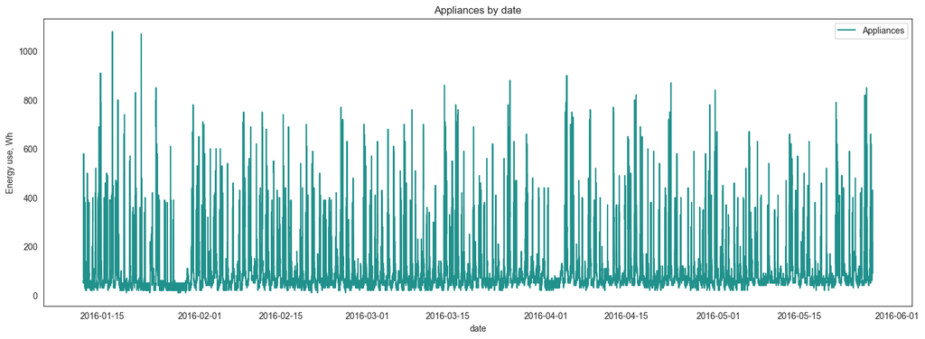

```python
plt.figure(figsize=(18,6))
sns.lineplot(df, x='date', y='Appliances', color=palette_color[3], label='Appliances')
plt.title('Appliances by date')
plt.ylabel('Energy use, Wh')
plt.legend()
plt.show()
```

```python
print('Количество уникальных значений целевой переменной:',df['Appliances'].nunique())
```

```
Количество уникальных значений целевой переменной: 92
```

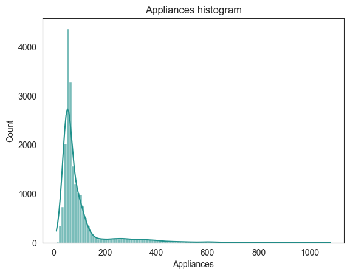

```python
sns.histplot(df['Appliances'], binwidth=10, kde=True, color=palette_color[3], alpha = 0.6)
plt.title('Appliances histogram')
plt.show()
```

## 1.3. Корреляции

Корреляционная матрица для всех признаков, кроме даты

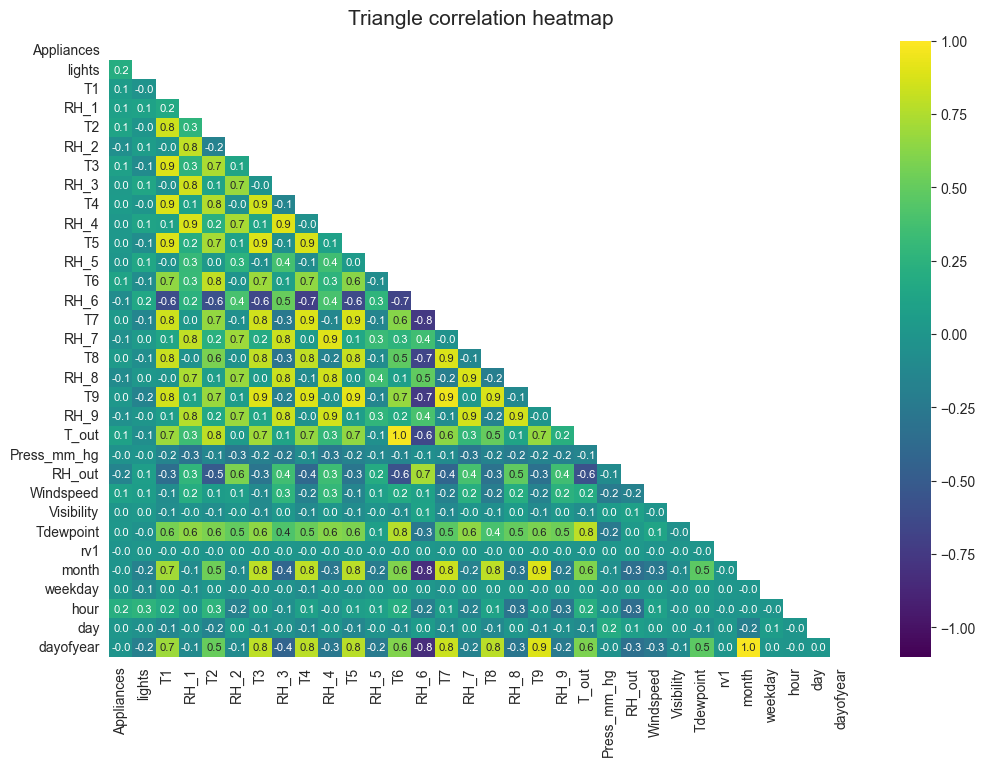

```python
corr_matr = df.select_dtypes(exclude='datetime').corr()

plt.figure(figsize=(12, 8))
mask = np.triu(np.ones_like(corr_matr, dtype='bool'))
heatmap = sns.heatmap(corr_matr, mask=mask,vmin=1, vmax=-1, annot=True, fmt=".1f", cmap=sns.color_palette("viridis", as_cmap=True), annot_kws={'size': 8})
heatmap.set_title('Triangle correlation heatmap', fontdict={'fontsize':15}, pad=12)
plt.show()
```

Видно, что среди признаков есть группы признаков про погоду (группа с температурами в доме, с влажностью воздуха в доме) которые сильно скореллированы между собой - так что есть проблема мультиколлинеарности.

Корреляции всех признаков с целевой переменной

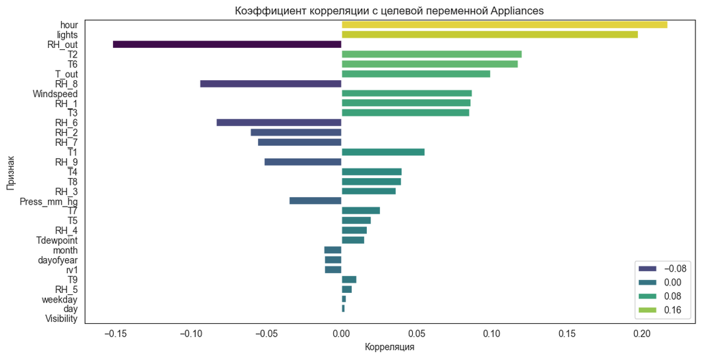

```
             corr_coef
hour          0.216792
lights        0.197278
RH_out       -0.152282
T2            0.120073
T6            0.117638
T_out         0.099155
RH_8         -0.094039
Windspeed     0.087122
RH_1          0.086031
T3            0.085060
RH_6         -0.083178
RH_2         -0.060465
RH_7         -0.055642
T1            0.055447
RH_9         -0.051462
T4            0.040281
T8            0.039572
RH_3          0.036292
Press_mm_hg  -0.034885
T7            0.025801
T5            0.019760
RH_4          0.016965
Tdewpoint     0.015353
month        -0.011606
dayofyear    -0.011214
rv1          -0.011145
T9            0.010010
RH_5          0.006955
weekday       0.003060
day           0.002366
Visibility    0.000230
```

```python
target_corr = pd.DataFrame(corr_matr['Appliances']).rename(columns={'Appliances':'corr_coef'})
target_corr.drop(index=['Appliances'], inplace=True)
target_corr.sort_values(by='corr_coef', key=abs, ascending = False, inplace=True)

plt.figure(figsize=(12, 6))

sns.barplot(y=target_corr.index, x= target_corr['corr_coef'], hue= target_corr['corr_coef'], palette='viridis')
plt.ylabel('Признак', fontsize=10)
plt.xlabel('Корреляция', fontsize=10)
plt.grid(False)
#sns.despine(left=True, bottom=True)
plt.title('Коэффициент корреляции с целевой переменной Appliances', fontsize=12)
plt.legend(loc='lower right')
plt.show()

print(target_corr)
```

Таким образом мы узнали, что самая значительная линейная зависимость у целевой переменной от признака hour, то есть от признака часа, но эта корреляция крайне мала.

## 1.4. Визуализации

Посмотрим и визуализируем некоторые зависимости Appliances от наших признаков

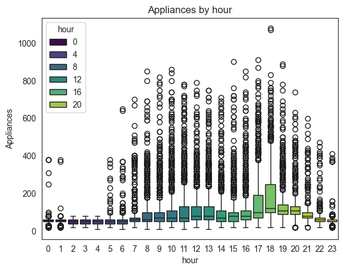

```python
sns.boxplot(df, y='Appliances', x='hour', hue='hour', palette='viridis')
plt.title('Appliances by hour')
plt.show()
```

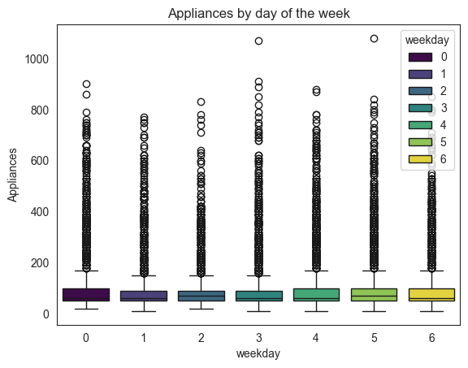

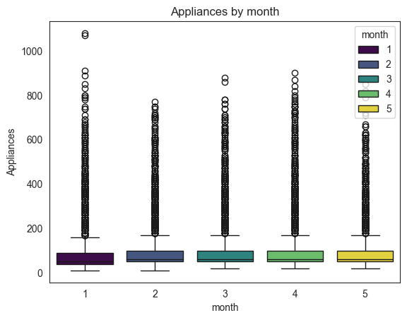

```python
sns.boxplot(df, y='Appliances', x='weekday', hue='weekday', palette='viridis')
plt.title('Appliances by day of the week')
plt.show()


sns.boxplot(df, y='Appliances', x='month', hue='month', palette='viridis')
plt.title('Appliances by month')
plt.show()
```

Данные графики выглядят очень сумбурно из-за большого количества выбросов. Кажется, что при таком значительном количестве выбросов - тактика их удаления очень повлияет на полноту данных

Чтобы лучше понять почасовые зависимости энергопотребления в разрезе дней недели и месяца, построим визуализации немного по-другому

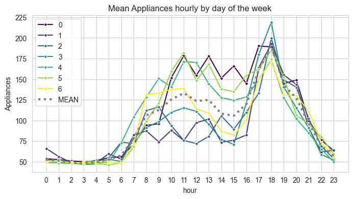

```python
sns.set_style('whitegrid')

df_weekday_hourly = pd.DataFrame(df.groupby(['weekday','hour'])['Appliances'].mean())
df_mean_hourly = df.groupby('hour')['Appliances'].mean()


plt.figure(figsize=(8,4))
sns.lineplot(df_weekday_hourly, x='hour', y='Appliances', hue='weekday', marker='o',markersize=4, palette='viridis')
sns.lineplot(df_mean_hourly, color='gray', linewidth = 3, label='MEAN', linestyle='dotted')

plt.xticks(range(24))
plt.title('Mean Appliances hourly by day of the week')
plt.legend()
plt.show()
```

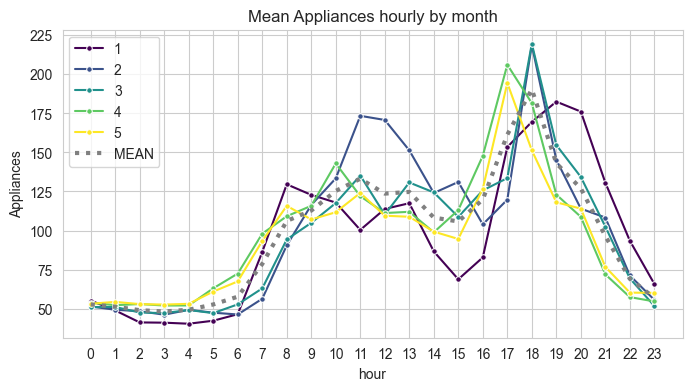

```python
sns.set_style('whitegrid')

df_month_hourly = pd.DataFrame(df.groupby(['month','hour'])['Appliances'].mean())
df_mean_hourly = df.groupby('hour')['Appliances'].mean()


plt.figure(figsize=(8,4))
sns.lineplot(df_month_hourly, x='hour', y='Appliances', hue='month', marker='o',markersize=4, palette='viridis')
sns.lineplot(df_mean_hourly, color='gray', linewidth = 3, label='MEAN', linestyle='dotted')

plt.xticks(range(24))
plt.title('Mean Appliances hourly by month')
plt.legend()
plt.show()
```

Определенно, графики почасового энергопотребления очень сильно меняются от дня недели и месяца

Построим тепловую карту нашего энергопотребления за весь период (каждый день и каждый час)

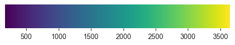

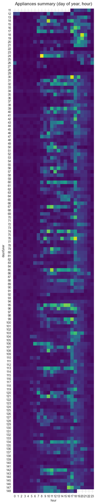

```python
df_day_hour_pivot = pd.pivot_table(df, values='Appliances', index=['dayofyear'],
                       columns=['hour'], aggfunc="sum")

cbar_ax = plt.axes([0, 0, 0.7, 0.1])

plt.figure(figsize=(5, 30))
ax = sns.heatmap(data = df_day_hour_pivot, annot=False, cmap=sns.color_palette("viridis", as_cmap=True),
                 cbar_ax=cbar_ax,
                cbar_kws={'orientation': 'horizontal'})
ax.set_title('Appliances summary (day of year, hour)', fontdict={'fontsize':15}, pad=12)
plt.show()
```

Как связаны Appliances и признак lights

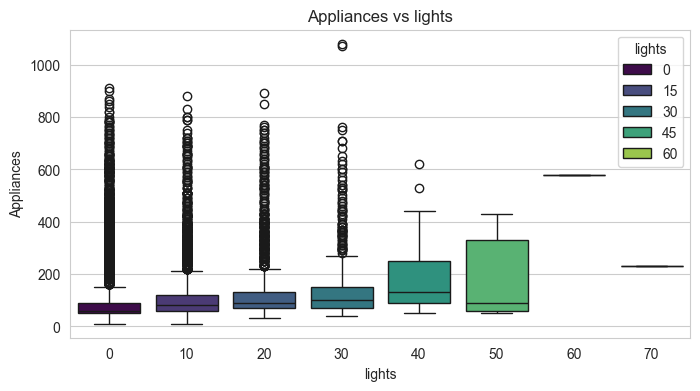

```python
sns.set_style('whitegrid')

plt.figure(figsize=(8,4))
sns.boxplot(df, x='lights', y='Appliances', hue='lights', palette = 'viridis')
plt.title('Appliances vs lights')
plt.show()
```

# 2. Временной ряд. Модель SARIMAX

К сожалению, мои попытки работать с полными данными по Appliances (каждые 10 минут = 144 измерений\сутки, и соответствующей сезонностью 144 даже на половине имеющегося датасета в качестве train) провалились из-за отсутствия необходимой вычислительной мощности.

Поэтому пришлось пожертвовать полнотой данных, чтобы смоделировать временные ряды, и усреднить данные по Appliances за каждый час

```python
series = df.groupby(by=['dayofyear','weekday','hour'], as_index=False)['Appliances'].mean()
series.head()
```

|  | dayofyear | weekday | hour | Appliances |
| --- | --- | --- | --- | --- |
| 0 | 11 | 0 | 17 | 55.000000 |
| 1 | 11 | 0 | 18 | 176.666667 |
| 2 | 11 | 0 | 19 | 173.333333 |
| 3 | 11 | 0 | 20 | 125.000000 |
| 4 | 11 | 0 | 21 | 103.333333 |

Проведем тест Дикки-Фуллера (ADF), чтобы проверить ряд на стационарность

```python
print('Тест Дикки-Фуллера для Appliances')
adf_result = adfuller(series['Appliances'])

adf_statistic = adf_result[0]
p_value = adf_result[1]
critical_values = adf_result[4]

print(f'ADF Statistic: {adf_statistic:.5f}')
print(f'p-value: {p_value:.5f}')
print('Critical Values:')
for key, value in critical_values.items():
    print(f'   {key}: {value:.5f}')

for key, value in critical_values.items():
    if adf_statistic < value:
        print(f'Ряд стационарен на уровне значимости {key}.')
        break
else:
    print(f'Ряд не стационарен на всех уровнях значимости.')
```

```
Тест Дикки-Фуллера для Appliances
ADF Statistic: -8.94889
p-value: 0.00000
Critical Values:
   1%: -3.43236
   5%: -2.86243
   10%: -2.56724
Ряд стационарен на уровне значимости 1%.
```

Разделение данных на train/test (последовательно)

```python
train_size = int(len(series) * 0.8)
train, test = series[:train_size], series[train_size:]
print(f"Данные разделены на train/test размерами: {train.shape[0]}/{test.shape[0]}")
```

```
Данные разделены на train/test размерами: 2632/658
```

Построим модель SARIMAX (сезонность =24). Сделаем предсказания для тестовой части данных, визуализируем и оценим предсказания по метрикам качества (MAE, RMSE, R2)

(Если попробовать использовать в качестве экзогенных параметров час= hour и день недели =weekday метрики становятся только хуже. Если использовать другие наши признаки - погодные, то откуда их потом брать для предсказаний в будущем, когда у нас не будет для них точных значений)

```
Модель SARIMAX:
```

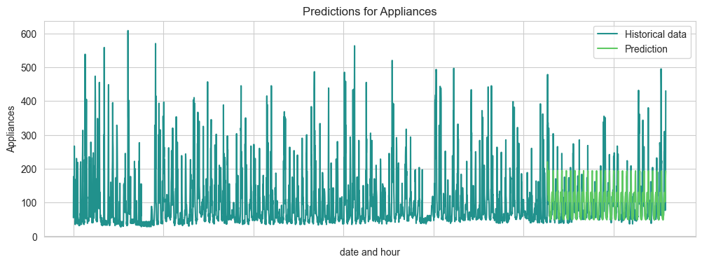

```
Метрики качества:
MAE: 36.8515
RMSE: 60.6979
R2: 0.2712

CPU times: total: 35.8 s
Wall time: 40.9 s
```

```python
%%time

exog_train = train[['weekday', 'hour']]
exog_test = test[['weekday', 'hour']]

print(f"Модель SARIMAX:")

series_train = train['Appliances']

model = SARIMAX(series_train,
                order=(1,1,1),
                seasonal_order=(1,1,1,24),
                #exog=exog_train,
                enforce_stationarity=False,
                enforce_invertibility=False)
model_fit = model.fit()

n_steps = test.shape[0]
forecast = model_fit.forecast(steps=n_steps,
                             # exog = exog_test
                             )
forecast_index = test.index

plt.figure(figsize=(12, 4))
sns.lineplot(x = series.index, y = series['Appliances'], color = palette_color[3],label='Historical data')
sns.lineplot(x = forecast_index, y = forecast, label='Prediction', color = palette_color[5])
plt.title(f'Predictions for Appliances')
plt.xlabel('date and hour')
plt.ylabel(f'Appliances')
plt.gca().set_xticklabels([])
plt.legend()
plt.show()

print('Метрики качества:')
mae = mean_absolute_error(test['Appliances'], forecast)
rmse = np.sqrt(mean_squared_error(test['Appliances'], forecast))
r2 = r2_score(test['Appliances'], forecast)
print(f'MAE: {mae:.4f}')
print(f'RMSE: {rmse:.4f}')
print(f'R2: {r2:.4f}',end='\n\n')
```

```python
# Модель auto-arima: работает очень долго и в итоге подбирает такие коэффициенты, что график предсказаний Appliances затухает в 0


# %%time

# print('Модель для Appliances auto-arima')

# series_train = train['Appliances']

# model = auto_arima(series_train,
#                    seasonal=True,
#                    #exogenous = exog_train,
#                    m=24,
#                    stepwise=True,
#                    trace=True)
# model_fit = model.fit(series_train)

# print(f"Лучшие параметры найденные auto-arima (p, d, q): {model_fit.order}; (P, D, Q, m): {model_fit.seasonal_order}")
# #print(model_fit.summary())
# n_steps = test.shape[0]
# forecast, conf_int = model_fit.predict(n_periods=n_steps,
#                                        #exogenous = exog_test,
#                                        return_conf_int=True)
# forecast_index = test.index
# plt.figure(figsize=(12, 4))
# sns.lineplot(x=series.index, y=series['Appliances'], color = palette_color[3],label='Historical data')
# sns.lineplot(x=forecast_index, y=forecast, label='Prediction', color = palette_color[5], marker='o', markersize=2)
# plt.title(f'Prediction for {column}')
# plt.xlabel('date and hour')
# plt.ylabel(f'Appliances')
# plt.legend()
# plt.show()

# print('Метрики качества:')
# mae = mean_absolute_error(test['Appliances'], forecast)
# rmse = np.sqrt(mean_squared_error(test['Appliances'], forecast))
# r2 = r2_score(test['Appliances'], forecast)
# print(f'MAE: {mae:.4f}')
# print(f'RMSE: {rmse:.4f}')
# print(f'R2: {r2:.4f}',end='\n\n')
```

**Вывод:**

В рамках задачи моделирования временных рядов для прогнозирования энергопотребления была рассмотрена модель SARIMAХ, которая справилась с задачей, но дала лишь удовлетворительные результаты прогнозирования на тестовых данных.

Для почасовых данных с указанием сезонности 24 часа (сутки) модель очень плохо справилась с предсказаниями пиковых значений

# 3. Модели

## 3.1. Подготовка train, test

Чтобы агрегировать итоги работы разных моделей подготовим таблицу с результатами метрик на тестовом и обучающем датасетах

```python
results = pd.DataFrame(columns = ['Название модели', 'MAE test', 'MSE test', 'RMSE test', 'R2 test', 'MAE train', 'MSE train', 'RMSE train', 'R2 train'])
results
```

|  | Название модели | MAE test | MSE test | RMSE test | R2 test | MAE train | MSE train | RMSE train | R2 train |
| --- | --- | --- | --- | --- | --- | --- | --- | --- | --- |

Вспомогательная функция для подсчета значений метрик по истинным и предсказанным значениям

```python
def my_metrics(y_train, y_test, y_train_pred, y_test_pred):
    mae_train = mean_absolute_error(y_train, y_train_pred)
    mse_train = mean_squared_error(y_train, y_train_pred)
    rmse_train = np.sqrt(mse_train)
    r2_train = r2_score(y_train, y_train_pred)

    mae_test = mean_absolute_error(y_test, y_test_pred)
    mse_test = mean_squared_error(y_test, y_test_pred)
    rmse_test = np.sqrt(mse_test)
    r2_test = r2_score(y_test, y_test_pred)

    return [mae_test, mse_test, rmse_test, r2_test, mae_train, mse_train, rmse_train, r2_train]
```

Подготовка train и test. Стандартизация обучающей и тестовой выборки с помощью Standard Scaler (обучение scaler только на обучающей части)

```python
X = df.drop(columns = ['date', 'dayofyear', 'Appliances'])
y = df['Appliances']

X_train, X_test, y_train, y_test = train_test_split(X,y, train_size = 0.8, random_state=42)
print(f'Train shapes X {X_train.shape}, y {y_train.shape}')
print(f'Test shapes X {X_test.shape}, y {y_test.shape}')

stscaler =  StandardScaler().fit(X_train)
X_train_scaled = stscaler.transform(X_train)
X_test_scaled = stscaler.transform(X_test)
```

```
Train shapes X (15788, 30), y (15788,)
Test shapes X (3947, 30), y (3947,)
```

## 3.2. Линейная регрессия

```python
lr_model = LinearRegression()
lr_model.fit(X_train_scaled, y_train)

y_train_pred = lr_model.predict(X_train_scaled)
y_test_pred = lr_model.predict(X_test_scaled)

results.loc[len(results)] = ['Linear Regression'] + my_metrics(y_train, y_test, y_train_pred, y_test_pred)
results
```

|  | Название модели | MAE test | MSE test | RMSE test | R2 test | MAE train | MSE train | RMSE train | R2 train |
| --- | --- | --- | --- | --- | --- | --- | --- | --- | --- |
| 0 | Linear Regression | 52.569734 | 8303.540929 | 91.123767 | 0.170234 | 53.087289 | 8836.942814 | 94.005015 | 0.169181 |

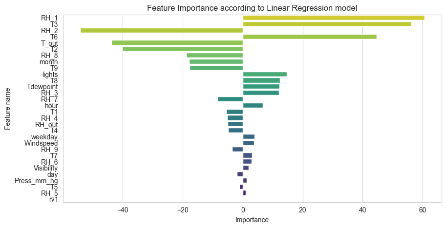

```
Самые значимые 10 признаков:
```

|  | Importance |
| --- | --- |
| RH_1 | 60.530678 |
| T3 | 56.287548 |
| RH_2 | -54.188254 |
| T6 | 44.622783 |
| T_out | -43.695901 |
| T2 | -40.224642 |
| RH_8 | -18.790386 |
| month | -17.908467 |
| T9 | -17.794300 |
| lights | 14.758681 |

```python
feature_importance_linreg = pd.DataFrame({'Importance': lr_model.coef_}, index=X_train.columns).sort_values(by='Importance', key=abs, ascending=False)

plt.figure(figsize=(10, 5))
sns.barplot(y = feature_importance_linreg.index, x = feature_importance_linreg['Importance'], hue = feature_importance_linreg.index, palette='viridis_r')
plt.title('Feature Importance according to Linear Regression model')
plt.ylabel('Feature name')
plt.show()

print('Самые значимые 10 признаков:')
feature_importance_linreg.head(10)
```

### 3.2.1. Дополнение по поводу признаков по Линейной регресии

Вместо большого количества признаков погодных - попытка перейти с помощью PCA к меньшему числу компонент (были испробованы переходы и по группам, а не все погодные признаки сразу, но это тоже неэффективно)

```
Всего погодных признаков 24
Principal Component 1: 0.388117 variance explained
Principal Component 2: 0.293902 variance explained
Principal Component 3: 0.075790 variance explained
Principal Component 4: 0.043938 variance explained
Principal Component 5: 0.040748 variance explained
Principal Component 6: 0.039175 variance explained
Principal Component 7: 0.023236 variance explained
Principal Component 8: 0.022045 variance explained
Principal Component 9: 0.016442 variance explained
Principal Component 10: 0.011225 variance explained
```

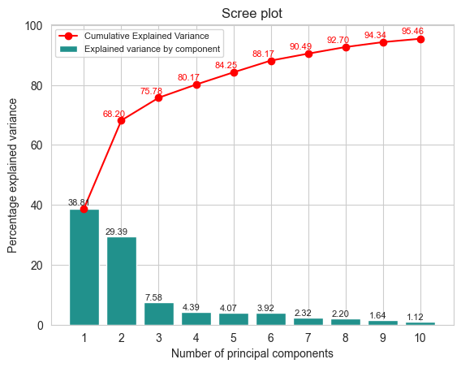

```python
from sklearn.decomposition import PCA

t_in_columns = ['T1', 'T2', 'T3', 'T4', 'T5', 'T6', 'T7', 'T8', 'T9']
rh_in_columns = ['RH_1', 'RH_2', 'RH_3', 'RH_4', 'RH_5', 'RH_6', 'RH_7', 'RH_8', 'RH_9']
out_columns = ['T_out','Press_mm_hg', 'RH_out', 'Windspeed', 'Visibility', 'Tdewpoint']

def display_scree_plot(pca, log_flag_scale=False):
    scree = pca.explained_variance_ratio_*100
    fig, ax = plt.subplots()
    bars = ax.bar(np.arange(len(scree))+1, scree, color = palette_color[3], label='Explained variance by component')
    for i, bar in enumerate(bars):
        yval = bar.get_height()
        ax.text(bar.get_x() + bar.get_width() / 3, yval*1.01, f'{yval:.2f}', ha='center', va='bottom', fontsize=8)
    plt.plot(np.arange(len(scree))+1, scree.cumsum(),c="red",marker='o', label='Cumulative Explained Variance')
    for i, value in enumerate(scree.cumsum()[1:], start=2):
        ax.text(i-0.2, value*1.01, f'{value:.2f}', ha='center', va='bottom', fontsize=8, c='red')
    plt.xlabel("Number of principal components")
    plt.ylabel("Percentage explained variance")
    if log_flag_scale:
        ax.set_yscale('log')
        plt.title("Scree plot. NB! Y log scale")
    else:
        plt.title("Scree plot")
    plt.xticks(np.arange(1,len(scree)+1,1))
    ax.legend(fontsize=8)
    plt.show(block=False)

all_features = df[t_in_columns + rh_in_columns + out_columns]
print(f'Всего погодных признаков {len(t_in_columns + rh_in_columns + out_columns)}')
stdscaler = StandardScaler()
all_scaled = stdscaler.fit_transform(all_features)


pca = PCA(n_components=10)
all_pca = pca.fit_transform(all_scaled)
for i, variance in enumerate(pca.explained_variance_ratio_, start=1):
    print(f"Principal Component {i}: {variance:.6f} variance explained")
display_scree_plot(pca)
```

Но даже 7 новых PCA признаков из 24 исходных погодных признаков дадут объяснение 90.49% дисперссии. Попробуем построить линейную регрессию, убрав все исходные погодные признаки, заменив их на 7 новых PCA

Это кстати во многом решит проблему мультиколлинеарности (можно перестроить корр матрицу), но вопрос, улучшит ли это предсказания для новой модели линейной регрессии

```python
n = 7
pca_columns = [f"weather_pca_{i}" for i in range(1, n+1)]
pca = PCA(n_components=n)
all_pca = pca.fit_transform(all_scaled)

df0 = df.drop(columns = t_in_columns + rh_in_columns + out_columns)
df0[pca_columns] = all_pca

X_ = df0.drop(columns = ['date', 'dayofyear', 'Appliances'])
y_ = df['Appliances']

X_train_, X_test_, y_train_, y_test_ = train_test_split(X_,y_, train_size = 0.8, random_state=42)

stscaler_ =  StandardScaler().fit(X_train_)
X_train_scaled_ = stscaler_.transform(X_train_)
X_test_scaled_ = stscaler_.transform(X_test_)

lr_model_ = LinearRegression()
lr_model_.fit(X_train_scaled_, y_train_)

y_train_pred = lr_model_.predict(X_train_scaled_)
y_test_pred = lr_model_.predict(X_test_scaled_)

results.loc[len(results)] = ['Linear Regression (with pca weather components)'] + my_metrics(y_train_, y_test_, y_train_pred, y_test_pred)
results
```

|  | Название модели | MAE test | MSE test | RMSE test | R2 test | MAE train | MSE train | RMSE train | R2 train |
| --- | --- | --- | --- | --- | --- | --- | --- | --- | --- |
| 0 | Linear Regression | 52.569734 | 8303.540929 | 91.123767 | 0.170234 | 53.087289 | 8836.942814 | 94.005015 | 0.169181 |
| 1 | Linear Regression (with pca weather components) | 54.193755 | 9025.098176 | 95.000517 | 0.098130 | 55.305861 | 9732.970303 | 98.655817 | 0.084940 |

**Вывод:**

Была построена модель линейной регрессии для всех компонент и она справилась гораздо лучше (хотя в целом все равно плохо), чем модель линейной регрессии, для которой вместо сильно скоррелированных груп погодных признаков мы перешли к новым признакам полученным с помощью PCA

## 3.3. Lasso регрессия, Ridge регрессия

```python
lasso_model = Lasso(alpha=0.1)
lasso_model.fit(X_train_scaled, y_train)

y_train_pred = lasso_model.predict(X_train_scaled)
y_test_pred = lasso_model.predict(X_test_scaled)

results.loc[len(results)] = ['Lasso Regression (alpha=0.1)'] + my_metrics(y_train, y_test, y_train_pred, y_test_pred)
results
```

|  | Название модели | MAE test | MSE test | RMSE test | R2 test | MAE train | MSE train | RMSE train | R2 train |
| --- | --- | --- | --- | --- | --- | --- | --- | --- | --- |
| 0 | Linear Regression | 52.569734 | 8303.540929 | 91.123767 | 0.170234 | 53.087289 | 8836.942814 | 94.005015 | 0.169181 |
| 1 | Linear Regression (with pca weather components) | 54.193755 | 9025.098176 | 95.000517 | 0.098130 | 55.305861 | 9732.970303 | 98.655817 | 0.084940 |
| 2 | Lasso Regression (alpha=0.1) | 52.439291 | 8298.147477 | 91.094168 | 0.170773 | 52.963401 | 8842.537478 | 94.034767 | 0.168655 |

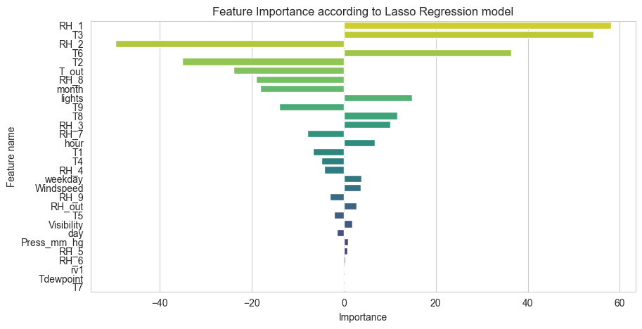

```
Самые значимые 10 признаков:
```

|  | Importance |
| --- | --- |
| RH_1 | 58.034484 |
| T3 | 54.246374 |
| RH_2 | -49.624532 |
| T6 | 36.395714 |
| T2 | -35.115559 |
| T_out | -23.967334 |
| RH_8 | -19.030598 |
| month | -18.076881 |
| lights | 14.866842 |
| T9 | -14.079463 |

```python
feature_importance_lasso = pd.DataFrame({'Importance': lasso_model.coef_}, index=X_train.columns).sort_values(by='Importance', key=abs, ascending=False)

plt.figure(figsize=(10, 5))
sns.barplot(y = feature_importance_lasso.index, x = feature_importance_lasso['Importance'], hue = feature_importance_lasso.index, palette='viridis_r')
plt.title('Feature Importance according to Lasso Regression model')
plt.ylabel('Feature name')
plt.show()

print('Самые значимые 10 признаков:')
feature_importance_lasso.head(10)
```

```python
ridge_model = Ridge(alpha=0.1)
ridge_model.fit(X_train_scaled, y_train)

y_train_pred = ridge_model.predict(X_train_scaled)
y_test_pred = ridge_model.predict(X_test_scaled)

results.loc[len(results)] = ['Ridge Regression'] + my_metrics(y_train, y_test, y_train_pred, y_test_pred)
results
```

|  | Название модели | MAE test | MSE test | RMSE test | R2 test | MAE train | MSE train | RMSE train | R2 train |
| --- | --- | --- | --- | --- | --- | --- | --- | --- | --- |
| 0 | Linear Regression | 52.569734 | 8303.540929 | 91.123767 | 0.170234 | 53.087289 | 8836.942814 | 94.005015 | 0.169181 |
| 1 | Linear Regression (with pca weather components) | 54.193755 | 9025.098176 | 95.000517 | 0.098130 | 55.305861 | 9732.970303 | 98.655817 | 0.084940 |
| 2 | Lasso Regression (alpha=0.1) | 52.439291 | 8298.147477 | 91.094168 | 0.170773 | 52.963401 | 8842.537478 | 94.034767 | 0.168655 |
| 3 | Ridge Regression | 52.569326 | 8303.518679 | 91.123645 | 0.170237 | 53.086888 | 8836.942862 | 94.005015 | 0.169181 |

Lasso и Ridge регрессия справились примерно также, как и просто линейная регрессия (хотя их применение может считаться одним из способов решения проблемы мультиколлинеарности)

## 3.4. RandomForestRegressor. Случайный лес

```python
rf_model = RandomForestRegressor(n_estimators=100)
rf_model.fit(X_train_scaled, y_train)

y_train_pred = rf_model.predict(X_train_scaled)
y_test_pred = rf_model.predict(X_test_scaled)

results.loc[len(results)] = ['Random Forest Regressor'] + my_metrics(y_train, y_test, y_train_pred, y_test_pred)
results
```

|  | Название модели | MAE test | MSE test | RMSE test | R2 test | MAE train | MSE train | RMSE train | R2 train |
| --- | --- | --- | --- | --- | --- | --- | --- | --- | --- |
| 0 | Linear Regression | 52.569734 | 8303.540929 | 91.123767 | 0.170234 | 53.087289 | 8836.942814 | 94.005015 | 0.169181 |
| 1 | Linear Regression (with pca weather components) | 54.193755 | 9025.098176 | 95.000517 | 0.098130 | 55.305861 | 9732.970303 | 98.655817 | 0.084940 |
| 2 | Lasso Regression (alpha=0.1) | 52.439291 | 8298.147477 | 91.094168 | 0.170773 | 52.963401 | 8842.537478 | 94.034767 | 0.168655 |
| 3 | Ridge Regression | 52.569326 | 8303.518679 | 91.123645 | 0.170237 | 53.086888 | 8836.942862 | 94.005015 | 0.169181 |
| 4 | Random Forest Regressor | 31.509577 | 4424.934094 | 66.520178 | 0.557820 | 12.272080 | 686.894641 | 26.208675 | 0.935421 |

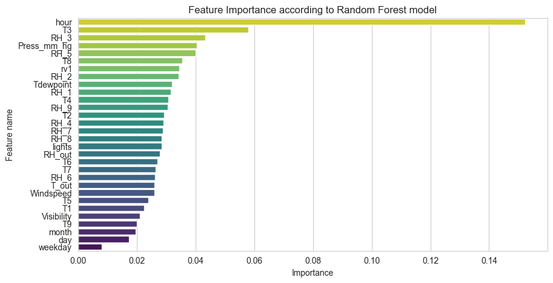

```
Самые значимые 10 признаков:
```

|  | Importance |
| --- | --- |
| hour | 0.152248 |
| T3 | 0.057936 |
| RH_3 | 0.043422 |
| Press_mm_hg | 0.040553 |
| RH_5 | 0.040074 |
| T8 | 0.035522 |
| rv1 | 0.034531 |
| RH_2 | 0.034335 |
| Tdewpoint | 0.032110 |
| RH_1 | 0.031526 |

```python
feature_importance_rf = pd.DataFrame({'Importance': rf_model.feature_importances_}, index=X_train.columns).sort_values(by='Importance', key=abs, ascending=False)

plt.figure(figsize=(10, 5))
sns.barplot(y = feature_importance_rf.index, x = feature_importance_rf['Importance'], hue = feature_importance_rf.index, palette='viridis_r')
plt.title('Feature Importance according to Random Forest model')
plt.ylabel('Feature name')
plt.show()

print('Самые значимые 10 признаков:')
feature_importance_rf.head(10)
```

Модель Случайного леса предсказала гораздо лучшие значения, и подчеркнула важности признака Hour (чего не наблюдалось раньше по важности признаков предшествующих моделей)

## 3.5. XGB Regressor

```python
xgb_model = xgb.XGBRegressor()

xgb_model.fit(X_train_scaled, y_train)

y_train_pred = xgb_model.predict(X_train_scaled)
y_test_pred = xgb_model.predict(X_test_scaled)

results.loc[len(results)] = ['XGB Regressor'] + my_metrics(y_train, y_test, y_train_pred, y_test_pred)
results
```

|  | Название модели | MAE test | MSE test | RMSE test | R2 test | MAE train | MSE train | RMSE train | R2 train |
| --- | --- | --- | --- | --- | --- | --- | --- | --- | --- |
| 0 | Linear Regression | 52.569734 | 8303.540929 | 91.123767 | 0.170234 | 53.087289 | 8836.942814 | 94.005015 | 0.169181 |
| 1 | Linear Regression (with pca weather components) | 54.193755 | 9025.098176 | 95.000517 | 0.098130 | 55.305861 | 9732.970303 | 98.655817 | 0.084940 |
| 2 | Lasso Regression (alpha=0.1) | 52.439291 | 8298.147477 | 91.094168 | 0.170773 | 52.963401 | 8842.537478 | 94.034767 | 0.168655 |
| 3 | Ridge Regression | 52.569326 | 8303.518679 | 91.123645 | 0.170237 | 53.086888 | 8836.942862 | 94.005015 | 0.169181 |
| 4 | Random Forest Regressor | 31.509577 | 4424.934094 | 66.520178 | 0.557820 | 12.272080 | 686.894641 | 26.208675 | 0.935421 |
| 5 | XGB Regressor | 34.716710 | 4651.740830 | 68.203672 | 0.535156 | 22.329929 | 1531.068811 | 39.128874 | 0.856054 |

Улучшим работу XGB Regressor путем переделывания части признаков (отвечающих за дату и время) в категориальные

```python
categorical_columns = ['month', 'weekday', 'hour', 'day']
num_columns = ['lights', 'T1', 'RH_1', 'T2', 'RH_2', 'T3', 'RH_3', 'T4', 'RH_4', 'T5',
       'RH_5', 'T6', 'RH_6', 'T7', 'RH_7', 'T8', 'RH_8', 'T9', 'RH_9', 'T_out',
       'Press_mm_hg', 'RH_out', 'Windspeed', 'Visibility', 'Tdewpoint', 'rv1']

X_train_rgb = X_train[categorical_columns + num_columns]
X_train_rgb[categorical_columns] = X_train_rgb[categorical_columns].astype('category')

X_test_rgb = X_test[categorical_columns + num_columns]
X_test_rgb[categorical_columns] = X_test_rgb[categorical_columns].astype('category')
```

```python
xgb_model_category = xgb.XGBRegressor(enable_categorical = True)

xgb_model_category.fit(X_train_rgb, y_train)

y_train_pred = xgb_model_category.predict(X_train_rgb)
y_test_pred = xgb_model_category.predict(X_test_rgb)

results.loc[len(results)] = ['XGB Regressor with categoriсal features'] + my_metrics(y_train, y_test, y_train_pred, y_test_pred)
results
```

|  | Название модели | MAE test | MSE test | RMSE test | R2 test | MAE train | MSE train | RMSE train | R2 train |
| --- | --- | --- | --- | --- | --- | --- | --- | --- | --- |
| 0 | Linear Regression | 52.569734 | 8303.540929 | 91.123767 | 0.170234 | 53.087289 | 8836.942814 | 94.005015 | 0.169181 |
| 1 | Linear Regression (with pca weather components) | 54.193755 | 9025.098176 | 95.000517 | 0.098130 | 55.305861 | 9732.970303 | 98.655817 | 0.084940 |
| 2 | Lasso Regression (alpha=0.1) | 52.439291 | 8298.147477 | 91.094168 | 0.170773 | 52.963401 | 8842.537478 | 94.034767 | 0.168655 |
| 3 | Ridge Regression | 52.569326 | 8303.518679 | 91.123645 | 0.170237 | 53.086888 | 8836.942862 | 94.005015 | 0.169181 |
| 4 | Random Forest Regressor | 31.509577 | 4424.934094 | 66.520178 | 0.557820 | 12.272080 | 686.894641 | 26.208675 | 0.935421 |
| 5 | XGB Regressor | 34.716710 | 4651.740830 | 68.203672 | 0.535156 | 22.329929 | 1531.068811 | 39.128874 | 0.856054 |
| 6 | XGB Regressor with categoriсal features | 34.127045 | 4662.117693 | 68.279702 | 0.534119 | 20.529850 | 1315.651924 | 36.271916 | 0.876307 |

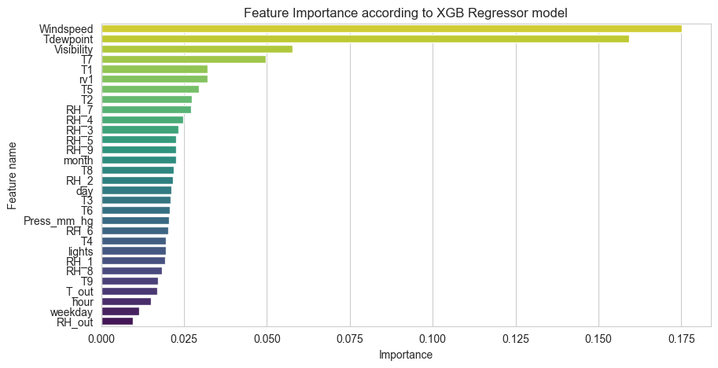

```
Самые значимые 10 признаков:
```

|  | Importance |
| --- | --- |
| Windspeed | 0.175157 |
| Tdewpoint | 0.159322 |
| Visibility | 0.057676 |
| T7 | 0.049548 |
| T1 | 0.032157 |
| rv1 | 0.032155 |
| T5 | 0.029474 |
| T2 | 0.027399 |
| RH_7 | 0.027218 |
| RH_4 | 0.024724 |

```python
feature_importance_xgb = pd.DataFrame({'Importance': xgb_model.feature_importances_}, index=X_train_rgb.columns).sort_values(by='Importance', key=abs, ascending=False)

plt.figure(figsize=(10, 5))
sns.barplot(y = feature_importance_xgb.index, x = feature_importance_xgb['Importance'], hue = feature_importance_xgb.index, palette='viridis_r')
plt.title('Feature Importance according to XGB Regressor model')
plt.ylabel('Feature name')
plt.show()

print('Самые значимые 10 признаков:')
feature_importance_xgb.head(10)
```

## 3.6. CatBoost

Последняя модель- CatBoost. Также как и XGB умеет работать с категориальными данными, так что для обучения и теста используем полученные на предыдущем шаге датасеты (от xgb)

```python
model_catboost = CatBoostRegressor(verbose = 100)
model_catboost.fit(X_train_rgb, y_train, cat_features=categorical_columns)

y_train_pred = model_catboost.predict(X_train_rgb)
y_test_pred = model_catboost.predict(X_test_rgb)

results.loc[len(results)] = ['CatBoost Regressor with categoriсal features'] + my_metrics(y_train, y_test, y_train_pred, y_test_pred)
results
```

```
Learning rate set to 0.063316
0:	learn: 101.9772257	total: 181ms	remaining: 3m 1s
100:	learn: 81.5991999	total: 3.71s	remaining: 33.1s
200:	learn: 76.9454845	total: 6.7s	remaining: 26.6s
300:	learn: 73.0834866	total: 9.72s	remaining: 22.6s
400:	learn: 70.3303074	total: 12.6s	remaining: 18.9s
500:	learn: 67.9966671	total: 15.6s	remaining: 15.5s
600:	learn: 65.8793719	total: 19s	remaining: 12.6s
700:	learn: 63.8717010	total: 22.2s	remaining: 9.47s
800:	learn: 61.9502722	total: 25.3s	remaining: 6.28s
900:	learn: 60.3301590	total: 28.2s	remaining: 3.1s
999:	learn: 58.7181780	total: 31.1s	remaining: 0us
```

|  | Название модели | MAE test | MSE test | RMSE test | R2 test | MAE train | MSE train | RMSE train | R2 train |
| --- | --- | --- | --- | --- | --- | --- | --- | --- | --- |
| 0 | Linear Regression | 52.569734 | 8303.540929 | 91.123767 | 0.170234 | 53.087289 | 8836.942814 | 94.005015 | 0.169181 |
| 1 | Linear Regression (with pca weather components) | 54.193755 | 9025.098176 | 95.000517 | 0.098130 | 55.305861 | 9732.970303 | 98.655817 | 0.084940 |
| 2 | Lasso Regression (alpha=0.1) | 52.439291 | 8298.147477 | 91.094168 | 0.170773 | 52.963401 | 8842.537478 | 94.034767 | 0.168655 |
| 3 | Ridge Regression | 52.569326 | 8303.518679 | 91.123645 | 0.170237 | 53.086888 | 8836.942862 | 94.005015 | 0.169181 |
| 4 | Random Forest Regressor | 31.509577 | 4424.934094 | 66.520178 | 0.557820 | 12.272080 | 686.894641 | 26.208675 | 0.935421 |
| 5 | XGB Regressor | 34.716710 | 4651.740830 | 68.203672 | 0.535156 | 22.329929 | 1531.068811 | 39.128874 | 0.856054 |
| 6 | XGB Regressor with categoriсal features | 34.127045 | 4662.117693 | 68.279702 | 0.534119 | 20.529850 | 1315.651924 | 36.271916 | 0.876307 |
| 7 | CatBoost Regressor with categoriсal features | 37.677909 | 5209.677387 | 72.178095 | 0.479401 | 31.227437 | 3332.584229 | 57.728539 | 0.686682 |

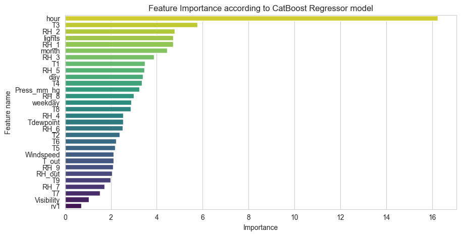

```
Самые значимые 10 признаков:
```

|  | Importance |
| --- | --- |
| hour | 16.247476 |
| T3 | 5.770087 |
| RH_2 | 4.780047 |
| lights | 4.725948 |
| RH_1 | 4.706611 |
| month | 4.458924 |
| RH_3 | 3.878176 |
| T1 | 3.478808 |
| RH_5 | 3.457519 |
| day | 3.399585 |

```python
feature_importance_catboost = pd.DataFrame({'Importance': model_catboost.get_feature_importance()}, index=X_train_rgb.columns).sort_values(by='Importance', key=abs, ascending=False)

plt.figure(figsize=(10, 5))
sns.barplot(y = feature_importance_catboost.index, x = feature_importance_catboost['Importance'], hue = feature_importance_catboost.index, palette='viridis_r')
plt.title('Feature Importance according to CatBoost Regressor model')
plt.ylabel('Feature name')
plt.show()

print('Самые значимые 10 признаков:')
feature_importance_catboost.head(10)
```

CatBoost распределил важность признаков очень похоже на модель случайного леса, но по оценке метрик и на тестовом и на тренировочном датасете значительно уступил модели RandomForest

# 4. Заключение

```python
results = results.sort_values(by='R2 test', ascending=False)
results
```

|  | Название модели | MAE test | MSE test | RMSE test | R2 test | MAE train | MSE train | RMSE train | R2 train |
| --- | --- | --- | --- | --- | --- | --- | --- | --- | --- |
| 4 | Random Forest Regressor | 31.509577 | 4424.934094 | 66.520178 | 0.557820 | 12.272080 | 686.894641 | 26.208675 | 0.935421 |
| 5 | XGB Regressor | 34.716710 | 4651.740830 | 68.203672 | 0.535156 | 22.329929 | 1531.068811 | 39.128874 | 0.856054 |
| 6 | XGB Regressor with categoriсal features | 34.127045 | 4662.117693 | 68.279702 | 0.534119 | 20.529850 | 1315.651924 | 36.271916 | 0.876307 |
| 7 | CatBoost Regressor with categoriсal features | 37.677909 | 5209.677387 | 72.178095 | 0.479401 | 31.227437 | 3332.584229 | 57.728539 | 0.686682 |
| 2 | Lasso Regression (alpha=0.1) | 52.439291 | 8298.147477 | 91.094168 | 0.170773 | 52.963401 | 8842.537478 | 94.034767 | 0.168655 |
| 3 | Ridge Regression | 52.569326 | 8303.518679 | 91.123645 | 0.170237 | 53.086888 | 8836.942862 | 94.005015 | 0.169181 |
| 0 | Linear Regression | 52.569734 | 8303.540929 | 91.123767 | 0.170234 | 53.087289 | 8836.942814 | 94.005015 | 0.169181 |
| 1 | Linear Regression (with pca weather components) | 54.193755 | 9025.098176 | 95.000517 | 0.098130 | 55.305861 | 9732.970303 | 98.655817 | 0.084940 |

В результате данной работы мы построили для предсказаний целевой переменной несколько моделей.

Для каждой модели дополнительно были построены и визуализированы важность признаков, на которых работает модель

[figure not shown]

```python
cmap = plt.get_cmap('viridis');
plt.figure(figsize=(8, 1))
text = 'Спасибо за внимание!'
for i in range(len(text)):
    plt.text(0.05 + i*0.05, 0.5, text[i], fontsize=40, color=cmap(i / len(text)), ha='center')
plt.axis('off')
plt.show()
```